# Introduction to Python Project : FoodHub Data Analysis

### Problem Statement

FoodHub is a food aggregator app in the New Yotk that offers access to multiple restaurants through a single smartphone app. The customers can place online orders at the restaurants and the app assigns a delivery partner from the company to pick up the order from the restaurant once it is confirmed. Once the food is packed, the delivery partner delivers the order to the customer and also the customer can track the delivery process through the app. The customers can rate the order in the app. FoodHub earns money by collecting a fixed margin on the delivery order from the restaurants.

### Objective

FoodHub wants to analyze the customer data to get an idea about the demand of different restaurants in order to improve the customer experience. As a Data Scientist, the task is to analyse the data to find the answers to the key business questions and provide insights that can help the company improve its business.

### Data Dictionary

- order_id: Unique ID of the order.
- customer_id: Id of the customer who ordered the food.
- restaurant_name: Name of the restaurant.
- cuisine_type: Type of the cuisine ordered by the customer.
- cost_of_the_order: Cost of the order (in dollars).
- day_of_the_week: Denotes if the order is placed on weekday or weekend.
- rating: Rating given by customer out of 5.
- food_preparation_time: Time taken by the restaurant to prepare the food (in minutes). It is calcuated by taking the difference between the restaurant's order confirmation and the delivery person's pick-up confirmation.
- delivery_time: Time taken by the delivery person to deliver the food (in minutes). It is calcuated by taking the difference between the delivery person's pick-up confirmation and drop-off information.

### Let us start by importing the required libraries

```python
# Write your code here to import necessary libraries for the project
import numpy as np
import pandas as pd
import matplotlib.pyplot as plt
import seaborn as sns
```

### Understanding the structure of the data

```python
# uncomment and run the following lines for Google Colab
from google.colab import drive
drive.mount('/content/drive')
```

```python
# Write your code here to read the data
data = pd.read_csv('/content/drive/MyDrive/FoodHub Data Analysis/foodhub_order.csv')
```

```python
# Write your code here to view the first 5 rows
data.head()
```

|  | order_id | customer_id | restaurant_name | cuisine_type | cost_of_the_order | day_of_the_week | rating | food_preparation_time | delivery_time |
| --- | --- | --- | --- | --- | --- | --- | --- | --- | --- |
| 0 | 1477147 | 337525 | Hangawi | Korean | 30.75 | Weekend | Not given | 25 | 20 |
| 1 | 1477685 | 358141 | Blue Ribbon Sushi Izakaya | Japanese | 12.08 | Weekend | Not given | 25 | 23 |
| 2 | 1477070 | 66393 | Cafe Habana | Mexican | 12.23 | Weekday | 5 | 23 | 28 |
| 3 | 1477334 | 106968 | Blue Ribbon Fried Chicken | American | 29.20 | Weekend | 3 | 25 | 15 |
| 4 | 1478249 | 76942 | Dirty Bird to Go | American | 11.59 | Weekday | 4 | 25 | 24 |

### **Question 1:** How many rows and columns are present in the data? [0.5 mark]

```python
# Write your code here
data.shape
```

```
(1898, 9)
```

#### Observations:

The data.shape is used to generate the number of rows and columns. Here the foodhub_order dataset has 1898 rows and 9 columns.

### **Question 2:** What are the datatypes of the different columns in the dataset? (The info() function can be used) [0.5 mark]

```python
# Write your code here
data.info()
```

```
<class 'pandas.core.frame.DataFrame'>
RangeIndex: 1898 entries, 0 to 1897
Data columns (total 9 columns):
 #   Column                 Non-Null Count  Dtype
---  ------                 --------------  -----
 0   order_id               1898 non-null   int64
 1   customer_id            1898 non-null   int64
 2   restaurant_name        1898 non-null   object
 3   cuisine_type           1898 non-null   object
 4   cost_of_the_order      1898 non-null   float64
 5   day_of_the_week        1898 non-null   object
 6   rating                 1898 non-null   object
 7   food_preparation_time  1898 non-null   int64
 8   delivery_time          1898 non-null   int64
dtypes: float64(1), int64(4), object(4)
memory usage: 133.6+ KB
```

#### Observations:

- There are 4 columns with integer (int64) values (datatype of order_id, customer_id, food_preparation_time and delivery_time).
- There are 4 columns with string (object) values (restaurant_name, cuisine_type, day_of_the_week and rating).
- There is 1 column with float (float64) value(cost_of_the order is float).

### **Question 3:** Are there any missing values in the data? If yes, treat them using an appropriate method. [1 mark]

```python
# Write your code here
data.isnull().sum()
```

|  | 0 |
| --- | --- |
| order_id | 0 |
| customer_id | 0 |
| restaurant_name | 0 |
| cuisine_type | 0 |
| cost_of_the_order | 0 |
| day_of_the_week | 0 |
| rating | 0 |
| food_preparation_time | 0 |
| delivery_time | 0 |

**dtype:** int64

```python
data.duplicated().sum()
```

```
np.int64(0)
```

### **Question 4:** Check the statistical summary of the data. What is the minimum, average, and maximum time it takes for food to be prepared once an order is placed? [2 marks]

```python
# Write your code here
data.describe()
```

|  | order_id | customer_id | cost_of_the_order | food_preparation_time | delivery_time |
| --- | --- | --- | --- | --- | --- |
| count | 1.898000e+03 | 1898.000000 | 1898.000000 | 1898.000000 | 1898.000000 |
| mean | 1.477496e+06 | 171168.478398 | 16.498851 | 27.371970 | 24.161749 |
| std | 5.480497e+02 | 113698.139743 | 7.483812 | 4.632481 | 4.972637 |
| min | 1.476547e+06 | 1311.000000 | 4.470000 | 20.000000 | 15.000000 |
| 25% | 1.477021e+06 | 77787.750000 | 12.080000 | 23.000000 | 20.000000 |
| 50% | 1.477496e+06 | 128600.000000 | 14.140000 | 27.000000 | 25.000000 |
| 75% | 1.477970e+06 | 270525.000000 | 22.297500 | 31.000000 | 28.000000 |
| max | 1.478444e+06 | 405334.000000 | 35.410000 | 35.000000 | 33.000000 |

```python
# Write your code here
min_time = data['food_preparation_time'].min()
print('The minimum time taken for food to be prepared once an order is placed is ' + str(min_time) + ' minutes.')
avg_time = data['food_preparation_time'].mean()
print('The average time taken for food to be prepared once an order is placed is ' + str(avg_time) + ' minutes.')
max_time = data['food_preparation_time'].max()
print('The maximum time taken for food to be prepared once an order is placed is ' + str(max_time) + ' minutes.')
```

```
The minimum time taken for food to be prepared once an order is placed is 20 minutes.
The average time taken for food to be prepared once an order is placed is 27.371970495258168 minutes.
The maximum time taken for food to be prepared once an order is placed is 35 minutes.
```

#### Observations:

**Statistical Summary**

- The cost_of_the_order ranges from 4.47 to 35.41 dollars.
- The average delivery_time is 24.16 minutes.
- The food_preparation_time ranges from 20 to 35 minutes.
- The minimum time for food to be prepared once an order is placed is 20 minutes, the average time is 27.37 minutes and maximum time is 35 minutes.

### **Question 5:** How many orders are not rated? [1 mark]

```python
# Write the code here
data[data['rating']=='Not given'].shape[0]
```

```
736
```

#### Observations:

There are 736 orders which are not rated.

### Exploratory Data Analysis (EDA)

### **Question 6:** Explore all the variables and provide observations on their distributions. (Generally, histograms, boxplots, countplots, etc. are used for univariate exploration.) [9 marks]

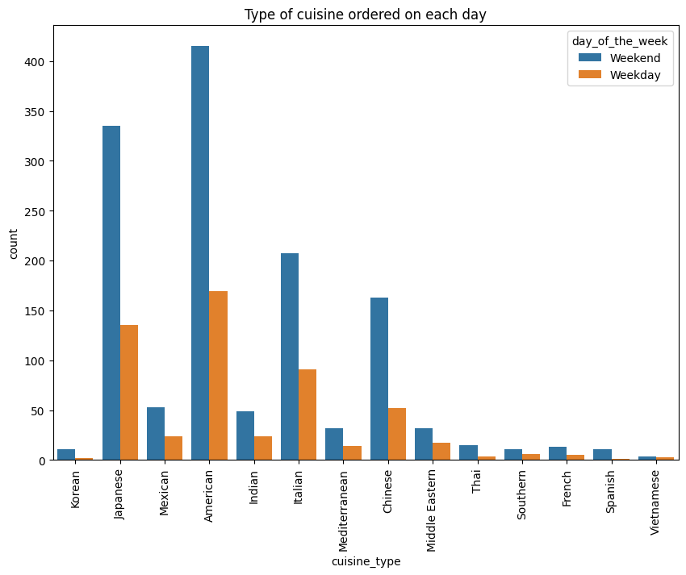

```python
# Write the code here
plt.figure(figsize=(10,7))
plt.xticks(rotation=90)
plt.title('Type of cuisine ordered on each day')
sns.countplot(data=data, x='cuisine_type', hue='day_of_the_week')
```

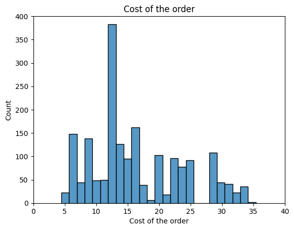

```python
plt.title('Cost of the order')
plt.xlim(0,40)
plt.ylim(0,400)
plt.xlabel('Cost of the order')
plt.ylabel('Count')
sns.histplot(data=data, x='cost_of_the_order', bins=25)
```

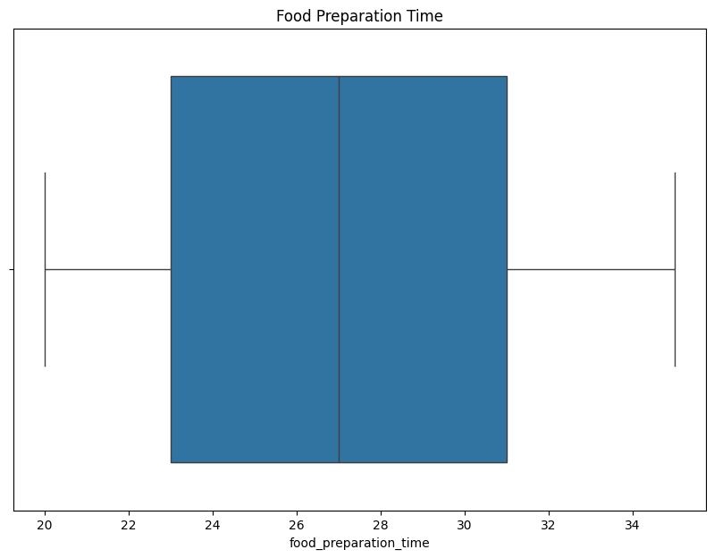

```python
plt.figure(figsize=(10,7))
plt.title('Food Preparation Time')
sns.boxplot(data=data, x='food_preparation_time')
```

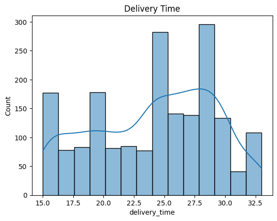

```python
plt.title('Delivery Time')
sns.histplot(data=data, x='delivery_time', kde=True)
```

### **Question 7**: Which are the top 5 restaurants in terms of the number of orders received? [1 mark]

```python
# Write the code here
data.groupby(['restaurant_name'])['order_id'].count().sort_values(ascending=False).head()
```

| restaurant_name | order_id |
| --- | --- |
| Shake Shack | 219 |
| The Meatball Shop | 132 |
| Blue Ribbon Sushi | 119 |
| Blue Ribbon Fried Chicken | 96 |
| Parm | 68 |

**dtype:** int64

#### Observations:

The top 5 restaurants in terms of the number of orders received are Shake Shack, The Meatball Shop, Blue Ribbon Sushi, Blue Ribbon Fried Chicken and Parm. The highest number of orders is at Shake Shack with 219 orders followed by The Meatball Shop with 132 orders.

### **Question 8**: Which is the most popular cuisine on weekends? [1 mark]

```python
# Write the code here
p_cuisine = data.cuisine_type[data.day_of_the_week == 'Weekend'].value_counts()
p_cuisine
```

| cuisine_type | count |
| --- | --- |
| American | 415 |
| Japanese | 335 |
| Italian | 207 |
| Chinese | 163 |
| Mexican | 53 |
| Indian | 49 |
| Middle Eastern | 32 |
| Mediterranean | 32 |
| Thai | 15 |
| French | 13 |
| Korean | 11 |
| Southern | 11 |
| Spanish | 11 |
| Vietnamese | 4 |

**dtype:** int64

```python
p_cuisine.head(1)
```

| cuisine_type | count |
| --- | --- |
| American | 415 |

**dtype:** int64

#### Observations:

The most popular cuisine on weekends is American cuisine with 415 orders.

### **Question 9**: What percentage of the orders cost more than 20 dollars? [2 marks]

```python
# Write the code here
order_value = data[data['cost_of_the_order']>20].shape[0]
percent_of_order = order_value/data.shape[0]*100
print(f'The percentage of the orders that cost more than 20 dollars is{ percent_of_order: .2f}%')
```

```
The percentage of the orders that cost more than 20 dollars is 29.24%
```

#### Observations:

The percentage of the orders cost more than 20$ is 29.24%.

### **Question 10**: What is the mean order delivery time? [1 mark]

```python
# Write the code here
m_del_time = round(data['delivery_time'].mean(),2)
print('The mean order delivery time is ' + str(m_del_time)+ ' minutes.')
```

```
The mean order delivery time is 24.16 minutes.
```

#### Observations:

The mean order delivery time is 24.16 minutes.

### **Question 11:** The company has decided to give 20% discount vouchers to the top 3 most frequent customers. Find the IDs of these customers and the number of orders they placed. [1 mark]

```python
# Write the code here
data.groupby(['customer_id'])['order_id'].count().sort_values(ascending=False).head(3)
```

| customer_id | order_id |
| --- | --- |
| 52832 | 13 |
| 47440 | 10 |
| 83287 | 9 |

**dtype:** int64

#### Observations:

The top 3 most frequent customers are:

1. customer_id - 52832 has placed 13 orders
2. customer_id - 47440 has placed 10 orders
3. customer_id - 83287 has placed 9 orders

### **Question 12**: Perform a multivariate analysis to explore relationships between the important variables in the dataset. (It is a good idea to explore relations between numerical variables as well as relations between numerical and categorical variables) [10 marks]

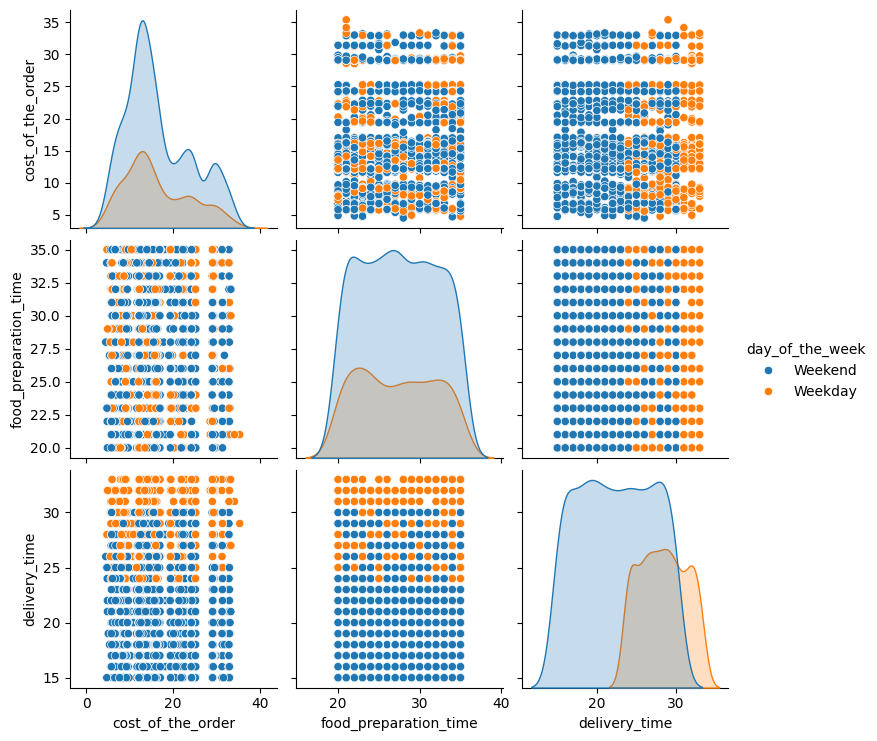

```python
# Write the code here
sns.pairplot(data=data, vars=['cost_of_the_order','food_preparation_time','delivery_time',],hue='day_of_the_week')
```

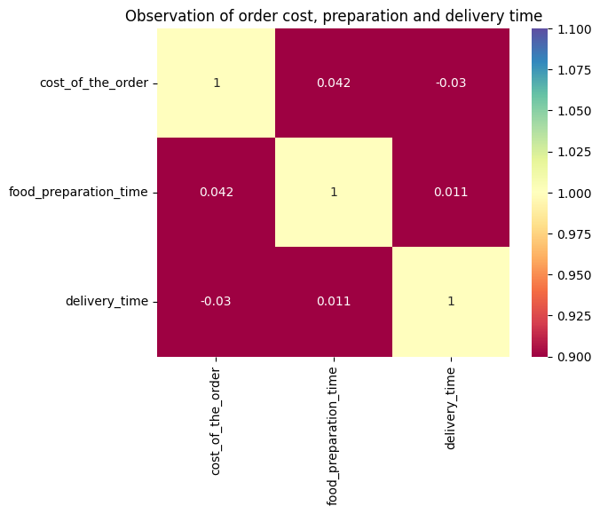

```python
plt.title('Observation of order cost, preparation and delivery time')
sns.heatmap(data=data[['cost_of_the_order', 'food_preparation_time', 'delivery_time']].corr(), annot=True, vmin=1, vmax=1, cmap='Spectral')
plt.show()
```

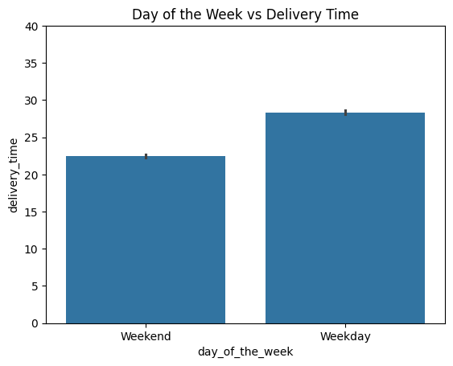

```python
plt.title('Day of the Week vs Delivery Time')
plt.ylim(0,40)
sns.barplot(data=data, x='day_of_the_week', y='delivery_time')
```

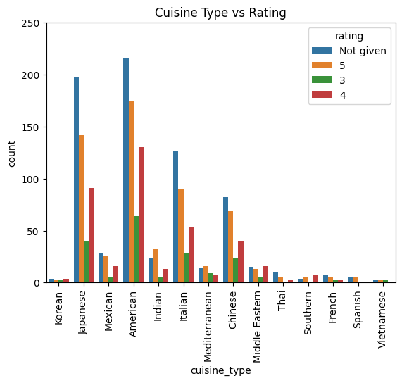

```python
plt.title('Cuisine Type vs Rating')
plt.xticks(rotation=90)
plt.ylim(0,250)
sns.countplot(data=data, x='cuisine_type', hue='rating')
```

### **Question 13:** The company wants to provide a promotional offer in the advertisement of the restaurants. The condition to get the offer is that the restaurants must have a rating count of more than 50 and the average rating should be greater than 4. Find the restaurants fulfilling the criteria to get the promotional offer. [3 marks]

```python
# Write the code here
fil_data = data[data['rating']!='Not given']
fil_data['rating'] = fil_data['rating'].astype('float')
res_rat = fil_data.groupby(['restaurant_name'])['rating'].agg(['count','mean']).reset_index()
final_res = res_rat[(res_rat['count']>50) & (res_rat['mean']>4)]
final_res
```

|  | restaurant_name | count | mean |
| --- | --- | --- | --- |
| 16 | Blue Ribbon Fried Chicken | 64 | 4.328125 |
| 17 | Blue Ribbon Sushi | 73 | 4.219178 |
| 117 | Shake Shack | 133 | 4.278195 |
| 132 | The Meatball Shop | 84 | 4.511905 |

#### Observations:

The Blue Ribbon Fried Chicken, Blue Ribbon Sushi, Shake Shack and The Meatball Shop are the restaurants that has the count above 50 and average rating above 4. Thus, these restaurants are eligible for the promotional offer in the advertisement of the restaurants.

### **Question 14:** The company charges the restaurant 25% on the orders having cost greater than 20 dollars and 15% on the orders having cost greater than 5 dollars. Find the net revenue generated by the company across all orders. [3 marks]

```python
# Write the code here
def net_revenue(cost_of_the_order):
  if cost_of_the_order > 20:
    return cost_of_the_order*0.25
  elif cost_of_the_order > 5:
    return cost_of_the_order*0.15
  else:
    return 0.0
data['revenue'] = data['cost_of_the_order'].apply(net_revenue)
net_revenue = data['revenue'].sum()
print(f'The net revenue generated by the company across all orders is {net_revenue: .2f} dollars.')
```

```
The net revenue generated by the company across all orders is  6166.30 dollars.
```

#### Observations:

A new column 'revenue' is created and the net revenue generated by the company across all the orders is 6166.30 dollars.

### **Question 15:** The company wants to analyze the total time required to deliver the food. What percentage of orders take more than 60 minutes to get delivered from the time the order is placed? (The food has to be prepared and then delivered.) [2 marks]

```python
# Write the code here
data['total_time'] = data['food_preparation_time'] + data['delivery_time']
total_time = data[data['total_time']>60]
percent_orders = (total_time.shape[0]/data.shape[0])*100
print(f'Percentage of orders that take more than 60 minutes to get delivered from the order placed time is {percent_orders:.2f}%')
```

```
Percentage of orders that take more than 60 minutes to get delivered from the order placed time is 10.54%
```

### **Question 16:** The company wants to analyze the delivery time of the orders on weekdays and weekends. How does the mean delivery time vary during weekdays and weekends? [2 marks]

```python
# Write the code here
data.groupby(['day_of_the_week'])['delivery_time'].sum()
```

| day_of_the_week | delivery_time |
| --- | --- |
| Weekday | 15502 |
| Weekend | 30357 |

**dtype:** int64

```python
# Write the code here
data.groupby(['day_of_the_week'])['delivery_time'].mean()
```

| day_of_the_week | delivery_time |
| --- | --- |
| Weekday | 28.340037 |
| Weekend | 22.470022 |

**dtype:** float64